# Sensitivity Subexponential

Andrea Brizzi

25/01/2022

## Maths

The objective is to study the adaptability of our EpiEstim adjustement to simulated data which do not satisfy the exponential growth scenario. In particular, we look at the subexponential case described in (Chowell 2016)[https://royalsocietypublishing.org/doi/10.1098/rsif.2016.0659]. Here they describe a simple modification of the SIR model to account for population mixing, which consists in modifying the transition rate from comparment S to I.
$$\frac{dS(t)}{dt} = -\beta S_t\frac{I^\alpha}{N} \\
= -I^{\alpha-1}\beta S_t \frac{I}{N}$$

## Simulations

### Plots

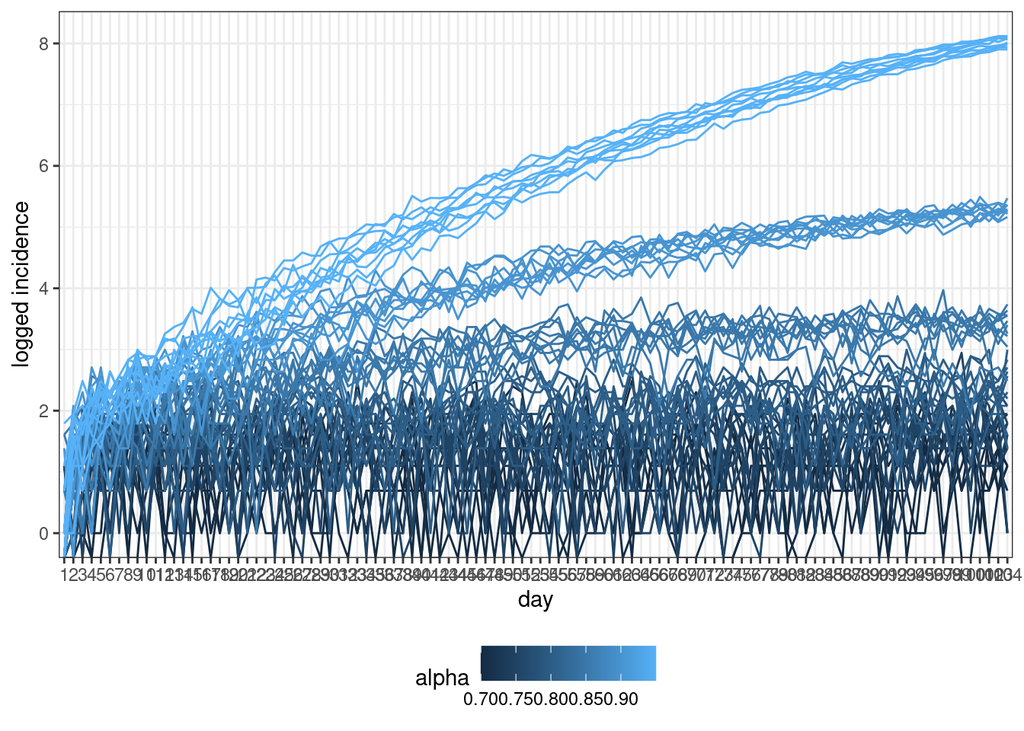

```r
sims <- lapply(c(0.7,0.75, 0.8, .85, 0.9, 0.95), function(x){
  tmp <- simulate_seir_stochastic(N=10, gamma=1/3, sigma=1/3.5, alpha=x, I0 = 30, arnaught=2, reporting_fraction = 1)$sims
  tmp <- as.data.frame(t(tmp))
  colnames(tmp) <- 1:ncol(tmp)
  tmp$alpha <- x
  tmp$sim <- gsub('sim','',rownames(tmp))
  tmp <- reshape2::melt(tmp, id.vars = c("alpha", "sim"))
  tmp <- tmp[order(as.numeric(tmp$sim)),]
  colnames(tmp)[c(3,4)] <- c('day', 'incidence')
  tmp
})
sims <- do.call("rbind", sims)
sims <- as.data.frame(sims)
sims$group <- paste0(sims$alpha, '_',sims$sim)
tmp <- sims

gg <- ggplot(data=sims, aes(x=day, y=log(incidence), color=alpha, group=group)) +
  geom_line() + theme_bw() + theme(legend.position='bottom') + labs(y='logged incidence')
gg
```

```r
ggsave(filename=file.path(plots_path, 'trajectories_subexponential.tiff'), gg + reqs, device = 'tiff', w=10, h=6, dpi=600)
```

### $R_t$ estimation

Here we compare the evolution of $R_t$ estimates using the different methods for a single simulation.

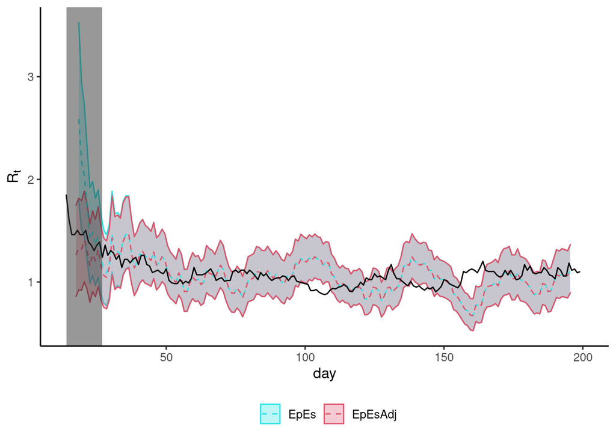

```r
rho <- 1;trueR0 <- 3; alpha <- .7

set.seed(43)
tmp <- simulate_seir_stochastic(N = 1, arnaught = trueR0,
                                gamma = 1/3, sigma = 1/3.5,
                                alpha=alpha,
                                reporting_fraction = 1,
                                N0_par = 10^6,
                                I0_par = 5,n_t=200)

I <- tmp$I[-length(tmp$I)]
incidence <- tmp$sims[,1]
incidence <- data.frame(cases = incidence, day = seq_along(incidence))
trueRt <- as.numeric(trueR0 * (1-cumsum(incidence$cases/10^6))) * I[-1]^{alpha-1}
trueRt[which(is.infinite(trueRt))] <- NA
trueRt <- data.frame(trueRt=trueRt, day=1:length(trueRt))


# Underreporting & missed generation
incidence$cases <- rbinom(n = length(incidence$cases),
                              size = incidence$cases,
                              prob = rho)
incidence <- filter(incidence, day >= 14)
first_day <- min(incidence$day)

# == apply normal EpiEstim
WINDOWS <- 7;
t_start <- 2:(length(incidence$cases) - WINDOWS)
t_end <- t_start + WINDOWS

epestim <- EpiEstim::estimate_R(c(incidence$cases), method = "parametric_si",
                           config = make_config(
                             list(
                               mean_si = mean_si,
                               std_si = sd_si,
                               t_start = t_start,
                               t_end = t_end
                             )))$R[,c("Mean(R)", "Quantile.0.025(R)", "Quantile.0.975(R)")]

epestim$day <- t_end + first_day - 1


# == Apply adjusted EpiEstim, using first 2 weeks to infer r.

# log transform cases, add small constant to time-series if zeros are present
if(any(incidence$cases==0)){
  incidence$casesC <- incidence$cases+0.5
  incidence$logcases <- log(incidence$casesC)
}else{
  incidence$logcases <- log(incidence$cases)
}

# Fit line through logged cases
exp_fit <- lm(logcases ~ day, data = filter(incidence, day >= first_day & day <= first_day + 13))

# introduce extrapolated data
tmp <- data.frame(day =  first_day - 1 + (-21):0)
tmp$logcases <- predict.lm(exp_fit, newdata = data.frame(day =  first_day - 1 + (-21):0 ))
if ("casesC" %in% names(incidence)){
  tmp$casesC <- exp(tmp$logcases)
  tmp$cases <- tmp$casesC - 0.5
  tmp$cases[tmp$cases < 0] <- 0
}else{
  tmp$cases <- exp(tmp$logcases)
}
# tmp$trueRt <- trueR0

incidence <- rbind(tmp, incidence)

# define windows
START <- which(incidence$day == first_day)
t_start <- START:(length(incidence$cases) - WINDOWS)
t_end <- t_start + WINDOWS

# add seeds...
epestim_adj <- EpiEstim::estimate_R(c(incidence$cases), method = "parametric_si",
                           config = make_config(
                             list(
                               mean_si = mean_si,
                               std_si = sd_si,
                               t_start = t_start,
                               t_end = t_end
                             )))$R[,c("Mean(R)", "Quantile.0.025(R)", "Quantile.0.975(R)")]

epestim_adj$day <- t_end - START + first_day

# COMPARE
# assign each estimate to the middle of the sliding window:
epestim$day <- epestim$day - WINDOWS/2
epestim_adj$day <- epestim_adj$day - WINDOWS/2

epestim$type = 'Unadjusted'
epestim_adj$type = 'Adjusted'
data <- rbind(epestim, epestim_adj)
colnames(data) <- c('M', 'Low', 'Up', 'day', 'type')
data$type <- gsub('Adjusted','EpEsAdj',data$type)
data$type <- gsub('Unadjusted', 'EpEs', data$type)

gg <- ggplot(data, aes(x = day)) +
  geom_ribbon(aes(ymin = Low , ymax = Up, color = type, fill = type), alpha = .3 ) +
  geom_line(aes(y = M, color = type), linetype = 'dashed') +
  geom_line(data=trueRt, aes(x = day, y = trueRt)) + xlim(c(14, 200)) +
  scale_fill_manual(values = c(5,2)) +
  scale_color_manual(values = c(5,2)) +
  theme_classic2() + theme(legend.position = 'bottom') +
  labs(y= expression("R"[t]), x='day', fill ='', color ='')

rect <- data.frame(xmin=first_day, xmax=first_day + 13, ymin=-Inf, ymax=Inf)
gg + geom_rect(data=rect, aes(xmin=xmin, xmax=xmax, ymin=ymin, ymax=ymax),
              fill="grey20",
              alpha=0.5,
              inherit.aes = FALSE)
```

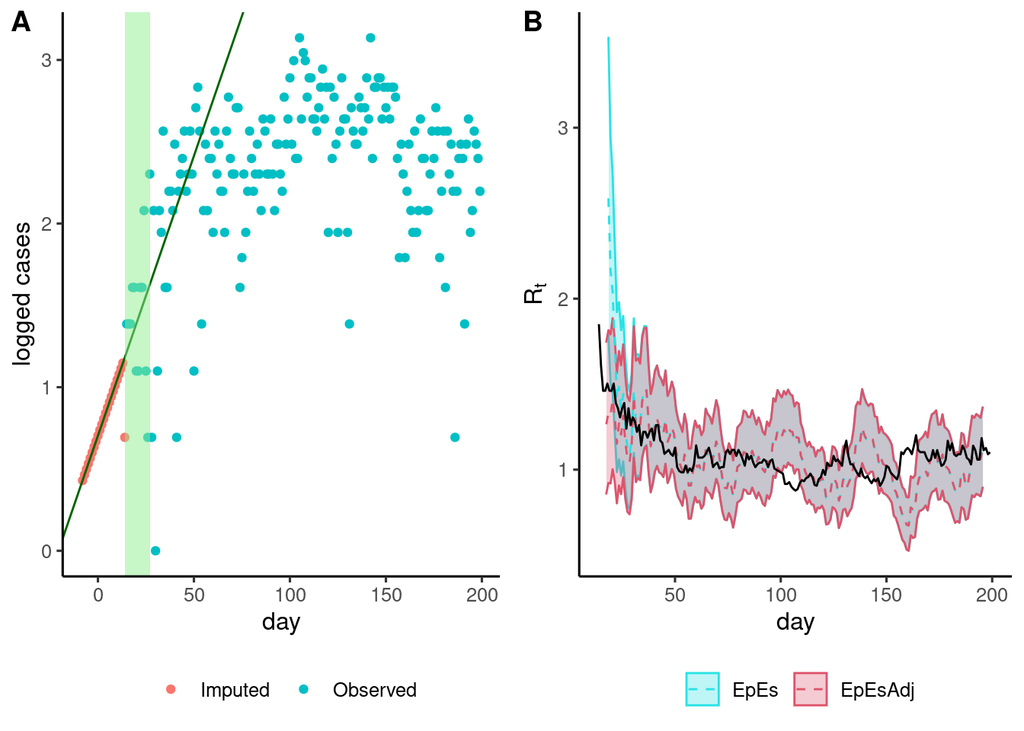

```r
incidence$before_first <- (incidence$day <= first_day)
incidence$before_first  <- sapply(incidence$before_first, FUN = function(x){if(x){'Imputed'}else{'Observed'}})

gg2 <- ggplot(incidence, aes(x= day, y = logcases, color = before_first )) +
  geom_point() +
  geom_abline(slope = exp_fit$coefficients[2], intercept = exp_fit$coefficients[1], color = 'darkgreen') +
  geom_rect(data=rect, aes(xmin=xmin, xmax=xmax, ymin=ymin, ymax=ymax),
              fill="lightgreen",
              alpha=0.5,
              inherit.aes = FALSE) +
  theme_classic2() +theme(legend.position = 'bottom') +
  labs(y = "logged cases", color = '' )

gg <- ggarrange(gg2, gg,
                 labels="AUTO")
gg
```

```r
ggsave(filename=file.path(plots_path, 'effects_adjustment_subexponential.tiff'), gg + reqs, device = 'tiff', w=10, h=5, dpi=600)
```